# Rumsay, Chapter 4: Summarizing quantitative data: means medians and more

Maurizio Murino

22 April 2016

```r
knitr::opts_chunk$set(cache=TRUE, warning=FALSE, message=FALSE, fig.width=4, echo = FALSE)
```

```r
library(knitr)
library(lattice)
```

### Exercise 1 - 22/4/’16

Is the data set shown in the following figure symmetric or skewed? How many modes does this data set have?

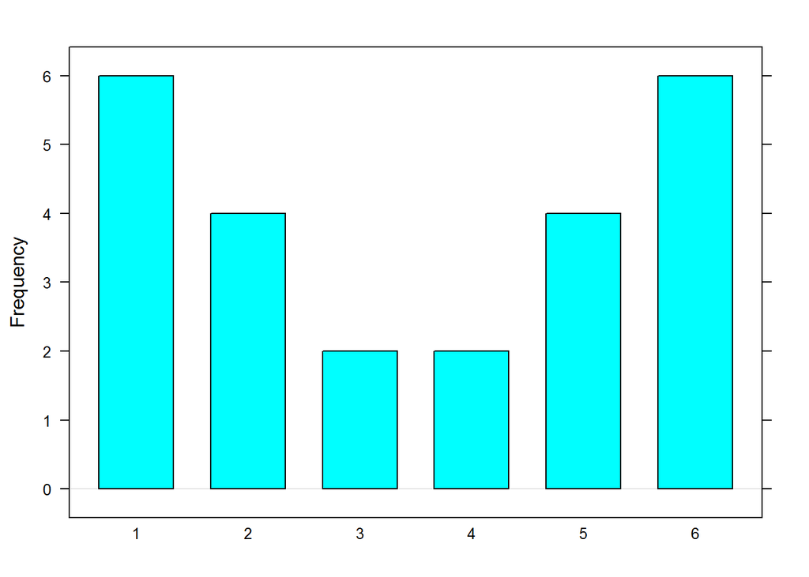

```r
e1 <- rep(seq(1, 6, 1), c(6, 4, 2, 2, 4, 6))
barchart(table(e1), horizontal = FALSE, xlab = "", ylab = "Frequency")
```

**Solution:** The data set is symmetric. Furthermore, it has two modes.

### Exercise 2 - 22/4/’16

Describe the shape of the dataset shown in the following figure.

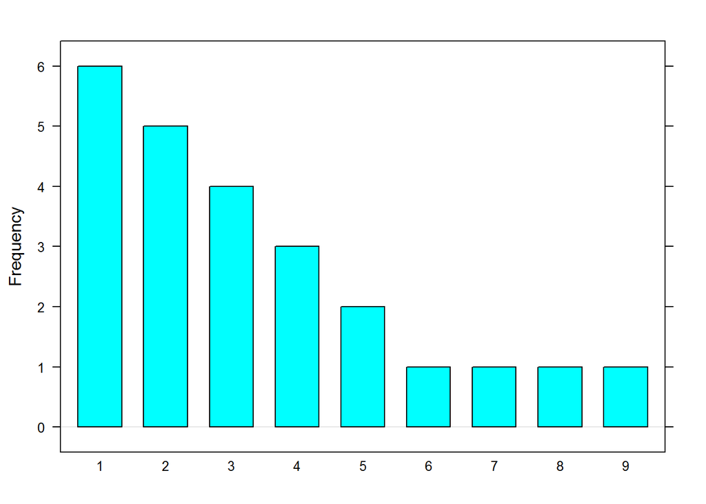

```r
e2 <- rep(seq(1, 9, 1), c(6, 5, 4, 3, 2, 1, 1, 1, 1))
barchart(table(e2), ylab = "Frequency", horizontal = FALSE)
```

**Solution:** The dataset is skewed, also said right skewed, with one mode.

### Exercise 3 - 23/4/’16

Describe the shape of the dataset shown in the following figure.

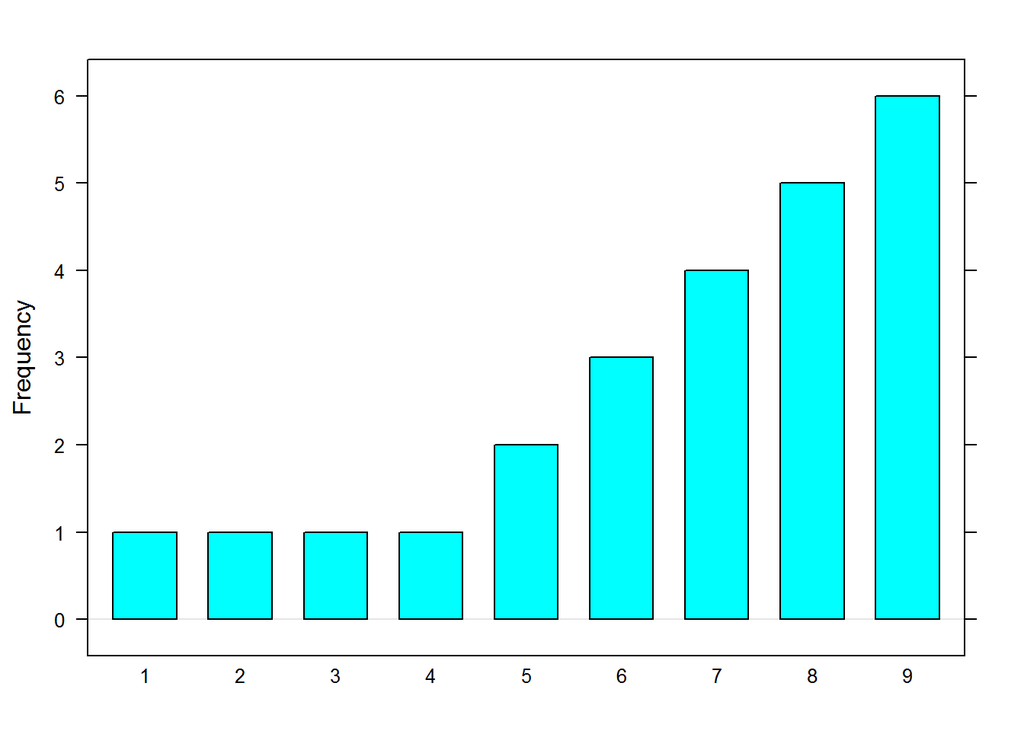

```r
e3 <- rep(seq(1, 9, 1), c(1, 1, 1, 1, 2, 3, 4, 5, 6))
barchart(table(e3), ylab = "Frequency", horizontal = FALSE)
```

**Solution:** The dataset is left skewed, with one mode.

### Exercise 4 - 23/4/’16

Give an example of a symmetric histogram with two modes.

**Solution:**

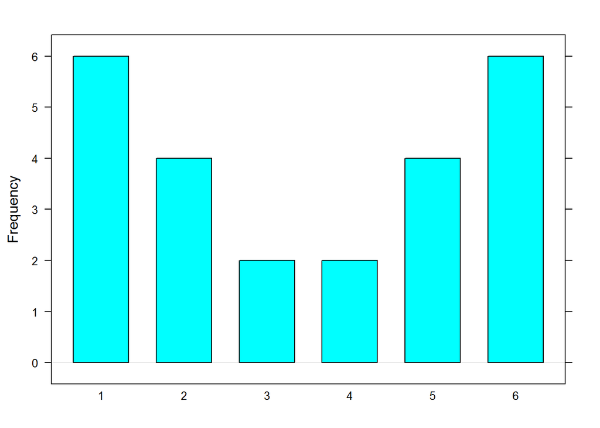

```r
e4 <- rep(seq(1, 6, 1), c(6, 4, 2, 2, 4, 6))
barchart(table(e4), ylab = "Frequency", horizontal = FALSE)
```

### Exercise 5 - 24/4/’16

Does the mean have to be one of the numbers on the data set? Explain.

### Exercise 6 - 24/4/’16

Does the median have to be one of the numbers on the data set? Explain.

**Solution:** No, it does not. The median is the value representing the $50^th$ percentile of a distribution, that is, the point with 50% of the ordered observation on the left and 50% on the right. Consider a distribution including 8, 6, 7, 5, 4. In this case, the median is 6, having two ordered observation for each side, 4, 5, 6, 7, 8. Instead, in a $n = 4$ distribution 8, 6, 4, 5 the median is 5.5, since it lies between 4, 5, *5.5*, 6, 7.

```r
a <- rnorm(100, 10, 2)
library(stargazer)
stargazer(a)
```

[output not shown]